# BRMS analysis | Posnalpha Behave | cue window | model EEG measures

Christopher Gundlach

2024-08-26

# Get everything up and running

## Initialize environment

**Setting up R libraries**

## load single trial data

Loading data D:/experimental_data/2024_PosnalphaBehave_Repository/data/eeg/Behavior_FFT_singletrials_cue.txt

The data has the following structure

- trialnumber = trial
- blocknumber
- trial_timing_type = 1=regular; 2=control
- cue_validity = 1=valid, 2=invalid, 3=neutral
- cue_validity_label
- cue_direction = 1=left, 2=right
- cue_direction_label
- cue_onset_fr = frame number of cue presentation
- cue_onset_t_est = onset time in ms
- cue_onset_t_meas = nan
- pre_event_type = 1=shorter, 2=longer, NaN=no event
- pre_event_onset_fr = onset frame of event
- pre_event_onset_t_est = onset time in ms
- pre_event_onset_t_meas = nan
- post_event_pos = position of post event: 1 = left, 2=right
- post_event_pos_label
- post_event_direction = direction of target (-90:90)=top;
- post_event_direction_c = category of target position: 1=top; 2=bottom
- post_event_direction_c_l = label
- post_event_dimenstion = size in degrees
- post_event_onset_fr = onset frames of event
- post_event_onset_t_est = onset times of events
- post_event_onset_t_meas = nan
- triggernum = trigger number
- pre_hit = empty=no event, TRUE=hit, 0=error, NaN=miss
- pre_RT = RT in ms
- post_hit = TRUE=hit, 0=error, NaN=miss
- post_RT = RT in ms
- subject
- FFT measures …

## wrangle data

from *long* formant to *longer* format

# Implementing the workflow

## Fitting the models

The models specified so far:

*SSVEP models*

- by visual alpha * validity: **SSVEP ~ vis_alpha * cue ( cue | subjects)**

*visual alpha models*

- contra target, validity model: **vis_alpha ~ cue + ( cue | subjects)**

*motor alpha models*

- contra target hand, validity model: **mot_alpha ~ cue + ( cue | subjects)**

```r
# alter data to extract post-cue visual alpha
modeldata2 = DATA.In_longer %>%
  filter(post_hit == "hit", signal == "visualAlpha", time == "[500 1500]ms")%>%
  mutate(visalpha = amplitude)

# just do the intercept model

fit_EEG_vis_alpha_intercept = brm(formula = visalpha ~ 1 + (1|subject),
          data = modeldata2,
          family = shifted_lognormal(),
          file = 'fit_EEGv2_vis_alpha_targ_intercept_slog',
          save_pars = save_pars(all = TRUE),
          # file_refit = "on_change",
          # file_refit = "always",
          file_refit = "never",
          cores = 4
          )  # Save all that hard work.


fit_EEG_vis_alpha_validity = brm(formula = visalpha ~ 1 + attention + (attention|subject),
          data = modeldata2,
          family = shifted_lognormal(),
          file = 'fit_EEGv2_vis_alpha_targ_validity_slog',
          save_pars = save_pars(all = TRUE),
          # file_refit = "on_change",
          # file_refit = "always",
          file_refit = "never",
          cores = 4
          )  # Save all that hard work.


# alter data to extract post-cue motor alpha
modeldata3 = DATA.In_longer %>%
  filter(post_hit == "hit", signal == "motorAlpha", time == "[500 1500]ms")%>%
  mutate(motalpha = amplitude)

fit_EEG_mot_alpha_intercept = brm(formula = motalpha ~ 1 + (1|subject),
          data = modeldata3,
          family = shifted_lognormal(),
          file = 'fit_EEGv2_mot_alpha_intercept_slog',
          save_pars = save_pars(all = TRUE),
          # file_refit = "on_change",
          # file_refit = "always",
          file_refit = "never",
          cores = 4
          )  # Save all that hard work.

fit_EEG_mot_alpha_validity = brm(formula = motalpha ~ 1 + attention + (attention|subject),
          data = modeldata3,
          family = shifted_lognormal(),
          file = 'fit_EEGv2_mot_alpha_validity_slog',
          save_pars = save_pars(all = TRUE),
          # file_refit = "on_change",
          # file_refit = "always",
          file_refit = "never",
          cores = 4
          )  # Save all that hard work.



modeldata3 = DATA.In_longer %>%
  filter(post_hit == "hit", signal != "motorAlpha", time == "[500 1500]ms")%>%
  dplyr::select(-Zamplitude)%>%
  pivot_wider(names_from = c(signal), values_from = amplitude)

fit_EEG_SSVEP_intercept = brm(formula = SSVEP ~ 1 + (1|subject),
          data = modeldata3,
          family = shifted_lognormal(),
          file = 'fit_EEGv2_SSVEP_intercept_slog',
          save_pars = save_pars(all = TRUE),
          # file_refit = "on_change",
          # file_refit = "always",
          file_refit = "never",
          cores = 4
          )  # Save all that hard work.

# * by visual alpha * validtiy: **target_SSVEP ~ vis_alpha * cue ( cue | subjects)**

fit_EEG_SSVEP_validity_x_alpha = brm(formula = SSVEP ~ attention * visualAlpha + (attention|subject),
          data = modeldata3,
          family = shifted_lognormal(),
          file = 'fit_EEGv2_SSVEP_validity_x_alpha_slog',
          save_pars = save_pars(all = TRUE),
          # file_refit = "on_change",
          # file_refit = "always",
          file_refit = "never",
          cores = 4
          )  # Save all that hard work.
```

### adding information criteria for all model estimates

this also takes some time as it is based on a cross validation procedure; but once run it is saved with the previously defined log file.

```r
# add relevant criteria for model comparison
# compare models

fit_EEG_vis_alpha_intercept <- add_criterion(fit_EEG_vis_alpha_intercept, c("loo", "waic", "bayes_R2"))

fit_EEG_mot_alpha_intercept<- add_criterion(fit_EEG_mot_alpha_intercept, c("loo", "waic", "bayes_R2"))

fit_EEG_SSVEP_intercept <- add_criterion(fit_EEG_SSVEP_intercept, c("loo", "waic", "bayes_R2"))


fit_EEG_vis_alpha_validity <- add_criterion(fit_EEG_vis_alpha_validity, c("loo", "waic", "bayes_R2"))

fit_EEG_mot_alpha_validity <- add_criterion(fit_EEG_mot_alpha_validity, c("loo", "waic", "bayes_R2"))

fit_EEG_SSVEP_validity_x_alpha <- add_criterion(fit_EEG_SSVEP_validity_x_alpha, c("loo", "waic", "bayes_R2"))
```

### display Bayesian R²

We can compute a Byesian version of the R² value for brms regression models for all the models.

```r
as.data.frame(rbind(
  bayes_R2(fit_EEG_vis_alpha_intercept),
  bayes_R2(fit_EEG_mot_alpha_intercept),
  bayes_R2(fit_EEG_SSVEP_intercept),
  bayes_R2(fit_EEG_vis_alpha_validity),
  bayes_R2(fit_EEG_mot_alpha_validity),
  bayes_R2(fit_EEG_SSVEP_validity_x_alpha)),
  row.names = c( "fit_EEG_vis_alpha_intercept",
                "fit_EEG_mot_alpha_intercept",
                "fit_EEG_SSVEP_intercept",
                "fit_EEG_vis_alpha_validity",
                "fit_EEG_mot_alpha_validity",
                "fit_EEG_SSVEP_validity_x_alpha"))%>%
  kable(escape = F, digits = c(6,6,6,6,6,6,6,6,6), caption = c("alpha, ssvep and combined models | bayes_R2")) %>%
  kable_styling("striped", full_width = T, bootstrap_options = c("striped", "hover", "condensed", "responsive",font_size = 8))
```

alpha, ssvep and combined models | bayes_R2

|  | Estimate | Est.Error | Q2.5 | Q97.5 |
| --- | --- | --- | --- | --- |
| fit_EEG_vis_alpha_intercept | 0.608798 | 0.004221 | 0.600371 | 0.616825 |
| fit_EEG_mot_alpha_intercept | 0.406788 | 0.005278 | 0.396446 | 0.417153 |
| fit_EEG_SSVEP_intercept | 0.260013 | 0.005563 | 0.249055 | 0.271008 |
| fit_EEG_vis_alpha_validity | 0.613222 | 0.004107 | 0.604917 | 0.621119 |
| fit_EEG_mot_alpha_validity | 0.416573 | 0.005176 | 0.406076 | 0.426573 |
| fit_EEG_SSVEP_validity_x_alpha | 0.262876 | 0.005318 | 0.252717 | 0.273254 |

```r
summary(fit_EEG_vis_alpha_intercept)
```

```
##  Family: shifted_lognormal
##   Links: mu = identity; sigma = identity; ndt = identity
## Formula: visalpha ~ 1 + (1 | subject)
##    Data: modeldata2 (Number of observations: 20656)
##   Draws: 4 chains, each with iter = 2000; warmup = 1000; thin = 1;
##          total post-warmup draws = 4000
##
## Group-Level Effects:
## ~subject (Number of levels: 28)
##               Estimate Est.Error l-95% CI u-95% CI Rhat Bulk_ESS Tail_ESS
## sd(Intercept)     0.52      0.07     0.39     0.69 1.03      192      297
##
## Population-Level Effects:
##           Estimate Est.Error l-95% CI u-95% CI Rhat Bulk_ESS Tail_ESS
## Intercept     1.52      0.11     1.31     1.75 1.02      172      245
##
## Family Specific Parameters:
##       Estimate Est.Error l-95% CI u-95% CI Rhat Bulk_ESS Tail_ESS
## sigma     0.33      0.00     0.32     0.33 1.01      673      754
## ndt       1.35      0.03     1.30     1.41 1.01      624      675
##
## Draws were sampled using sampling(NUTS). For each parameter, Bulk_ESS
## and Tail_ESS are effective sample size measures, and Rhat is the potential
## scale reduction factor on split chains (at convergence, Rhat = 1).
```

```r
summary(fit_EEG_mot_alpha_intercept)
```

```
##  Family: shifted_lognormal
##   Links: mu = identity; sigma = identity; ndt = identity
## Formula: motalpha ~ 1 + (1 | subject)
##    Data: modeldata3 (Number of observations: 20656)
##   Draws: 4 chains, each with iter = 2000; warmup = 1000; thin = 1;
##          total post-warmup draws = 4000
##
## Group-Level Effects:
## ~subject (Number of levels: 28)
##               Estimate Est.Error l-95% CI u-95% CI Rhat Bulk_ESS Tail_ESS
## sd(Intercept)     0.39      0.06     0.29     0.53 1.03      197      276
##
## Population-Level Effects:
##           Estimate Est.Error l-95% CI u-95% CI Rhat Bulk_ESS Tail_ESS
## Intercept     1.44      0.08     1.30     1.60 1.02      161      194
##
## Family Specific Parameters:
##       Estimate Est.Error l-95% CI u-95% CI Rhat Bulk_ESS Tail_ESS
## sigma     0.41      0.00     0.40     0.41 1.01      662     1186
## ndt       0.71      0.03     0.65     0.76 1.00      773     1201
##
## Draws were sampled using sampling(NUTS). For each parameter, Bulk_ESS
## and Tail_ESS are effective sample size measures, and Rhat is the potential
## scale reduction factor on split chains (at convergence, Rhat = 1).
```

```r
summary(fit_EEG_SSVEP_intercept)
```

```
##  Family: shifted_lognormal
##   Links: mu = identity; sigma = identity; ndt = identity
## Formula: SSVEP ~ 1 + (1 | subject)
##    Data: modeldata3 (Number of observations: 20656)
##   Draws: 4 chains, each with iter = 2000; warmup = 1000; thin = 1;
##          total post-warmup draws = 4000
##
## Group-Level Effects:
## ~subject (Number of levels: 28)
##               Estimate Est.Error l-95% CI u-95% CI Rhat Bulk_ESS Tail_ESS
## sd(Intercept)     0.39      0.06     0.30     0.53 1.03      184      322
##
## Population-Level Effects:
##           Estimate Est.Error l-95% CI u-95% CI Rhat Bulk_ESS Tail_ESS
## Intercept     1.32      0.08     1.17     1.48 1.03      189      369
##
## Family Specific Parameters:
##       Estimate Est.Error l-95% CI u-95% CI Rhat Bulk_ESS Tail_ESS
## sigma     0.58      0.00     0.57     0.58 1.00     1345     1553
## ndt       0.00      0.00     0.00     0.00 1.01      993      728
##
## Draws were sampled using sampling(NUTS). For each parameter, Bulk_ESS
## and Tail_ESS are effective sample size measures, and Rhat is the potential
## scale reduction factor on split chains (at convergence, Rhat = 1).
```

```r
summary(fit_EEG_vis_alpha_validity)
```

```
##  Family: shifted_lognormal
##   Links: mu = identity; sigma = identity; ndt = identity
## Formula: visalpha ~ 1 + attention + (attention | subject)
##    Data: modeldata2 (Number of observations: 20656)
##   Draws: 4 chains, each with iter = 2000; warmup = 1000; thin = 1;
##          total post-warmup draws = 4000
##
## Group-Level Effects:
## ~subject (Number of levels: 28)
##                              Estimate Est.Error l-95% CI u-95% CI Rhat Bulk_ESS Tail_ESS
## sd(Intercept)                    0.52      0.08     0.40     0.70 1.00      588     1254
## sd(attention.L)                  0.03      0.01     0.02     0.05 1.00     1477     2121
## sd(attention.Q)                  0.04      0.01     0.03     0.06 1.00     1590     2542
## cor(Intercept,attention.L)      -0.17      0.20    -0.54     0.25 1.00     1899     2469
## cor(Intercept,attention.Q)       0.22      0.20    -0.20     0.57 1.00     2019     2177
## cor(attention.L,attention.Q)    -0.75      0.16    -0.98    -0.37 1.00     1151     1281
##
## Population-Level Effects:
##             Estimate Est.Error l-95% CI u-95% CI Rhat Bulk_ESS Tail_ESS
## Intercept       1.53      0.10     1.32     1.72 1.02      323      580
## attention.L    -0.03      0.01    -0.04    -0.02 1.00     1556     2206
## attention.Q     0.01      0.01    -0.01     0.03 1.00     1782     2213
##
## Family Specific Parameters:
##       Estimate Est.Error l-95% CI u-95% CI Rhat Bulk_ESS Tail_ESS
## sigma     0.32      0.00     0.32     0.33 1.00     3512     2811
## ndt       1.34      0.03     1.29     1.40 1.00     3691     2724
##
## Draws were sampled using sampling(NUTS). For each parameter, Bulk_ESS
## and Tail_ESS are effective sample size measures, and Rhat is the potential
## scale reduction factor on split chains (at convergence, Rhat = 1).
```

```r
summary(fit_EEG_mot_alpha_validity)
```

```
##  Family: shifted_lognormal
##   Links: mu = identity; sigma = identity; ndt = identity
## Formula: motalpha ~ 1 + attention + (attention | subject)
##    Data: modeldata3 (Number of observations: 20656)
##   Draws: 4 chains, each with iter = 2000; warmup = 1000; thin = 1;
##          total post-warmup draws = 4000
##
## Group-Level Effects:
## ~subject (Number of levels: 28)
##                              Estimate Est.Error l-95% CI u-95% CI Rhat Bulk_ESS Tail_ESS
## sd(Intercept)                    0.39      0.06     0.30     0.52 1.00      525     1184
## sd(attention.L)                  0.06      0.01     0.05     0.09 1.00     1143     1945
## sd(attention.Q)                  0.01      0.01     0.00     0.03 1.00      916     1647
## cor(Intercept,attention.L)      -0.25      0.18    -0.57     0.12 1.00     1164     2086
## cor(Intercept,attention.Q)      -0.16      0.40    -0.85     0.71 1.00     3826     2305
## cor(attention.L,attention.Q)    -0.02      0.40    -0.79     0.78 1.00     3505     2338
##
## Population-Level Effects:
##             Estimate Est.Error l-95% CI u-95% CI Rhat Bulk_ESS Tail_ESS
## Intercept       1.46      0.08     1.31     1.60 1.04      303      672
## attention.L    -0.05      0.01    -0.07    -0.02 1.01      922     1107
## attention.Q    -0.02      0.01    -0.03    -0.00 1.00     5706     3347
##
## Family Specific Parameters:
##       Estimate Est.Error l-95% CI u-95% CI Rhat Bulk_ESS Tail_ESS
## sigma     0.40      0.00     0.40     0.41 1.00     3763     3017
## ndt       0.69      0.03     0.64     0.75 1.00     3768     2980
##
## Draws were sampled using sampling(NUTS). For each parameter, Bulk_ESS
## and Tail_ESS are effective sample size measures, and Rhat is the potential
## scale reduction factor on split chains (at convergence, Rhat = 1).
```

```r
summary(fit_EEG_SSVEP_validity_x_alpha)
```

```
##  Family: shifted_lognormal
##   Links: mu = identity; sigma = identity; ndt = identity
## Formula: SSVEP ~ attention * visualAlpha + (attention | subject)
##    Data: modeldata3 (Number of observations: 20656)
##   Draws: 4 chains, each with iter = 2000; warmup = 1000; thin = 1;
##          total post-warmup draws = 4000
##
## Group-Level Effects:
## ~subject (Number of levels: 28)
##                              Estimate Est.Error l-95% CI u-95% CI Rhat Bulk_ESS Tail_ESS
## sd(Intercept)                    0.39      0.06     0.30     0.52 1.00      449      904
## sd(attention.L)                  0.04      0.01     0.02     0.06 1.00     1498     1608
## sd(attention.Q)                  0.01      0.01     0.00     0.04 1.00     1464     1987
## cor(Intercept,attention.L)      -0.07      0.25    -0.54     0.42 1.00     2680     2636
## cor(Intercept,attention.Q)      -0.27      0.43    -0.91     0.68 1.00     3748     2441
## cor(attention.L,attention.Q)    -0.03      0.48    -0.87     0.84 1.00     3242     2647
##
## Population-Level Effects:
##                         Estimate Est.Error l-95% CI u-95% CI Rhat Bulk_ESS Tail_ESS
## Intercept                   1.30      0.08     1.14     1.45 1.03      184      378
## attention.L                 0.03      0.02    -0.01     0.06 1.00     2573     2832
## attention.Q                -0.01      0.02    -0.04     0.03 1.00     3498     2895
## visualAlpha                 0.00      0.00     0.00     0.01 1.00     8827     2759
## attention.L:visualAlpha    -0.00      0.00    -0.00     0.00 1.00     3068     3199
## attention.Q:visualAlpha    -0.00      0.00    -0.01     0.00 1.00     3424     2926
##
## Family Specific Parameters:
##       Estimate Est.Error l-95% CI u-95% CI Rhat Bulk_ESS Tail_ESS
## sigma     0.57      0.00     0.57     0.58 1.00     8351     2543
## ndt       0.00      0.00     0.00     0.00 1.00     3897     1848
##
## Draws were sampled using sampling(NUTS). For each parameter, Bulk_ESS
## and Tail_ESS are effective sample size measures, and Rhat is the potential
## scale reduction factor on split chains (at convergence, Rhat = 1).
```

## Extract marginal effects from visual alpha model

```r
# based on https://www.andrewheiss.com/blog/2021/11/10/ame-bayes-re-guide/
# which model to use?
bestmodel.ef.model <- fit_EEG_vis_alpha_validity
# what is the data of the model?
bestmodel.ef.data <- bestmodel.ef.model$data

# see data
#head(bestmodel.ef.data)

# show effects of the model
tidy(bestmodel.ef.model)%>%
  kable(escape = F, digits = c(6,6,6,6,6,6,6,6,6), caption = c("effects of best model")) %>%
  kable_styling("striped", full_width = T, bootstrap_options = c("striped", "hover", "condensed", "responsive",font_size = 8))
```

effects of best model

| effect | component | group | term | estimate | std.error | conf.low | conf.high |
| --- | --- | --- | --- | --- | --- | --- | --- |
| fixed | cond | NA | (Intercept) | 1.527373 | 0.101543 | 1.320133 | 1.719253 |
| fixed | cond | NA | attention.L | -0.029757 | 0.007496 | -0.044359 | -0.015235 |
| fixed | cond | NA | attention.Q | 0.008019 | 0.009950 | -0.011655 | 0.027681 |
| ran_pars | cond | subject | sd__(Intercept) | 0.520791 | 0.076577 | 0.400532 | 0.701289 |
| ran_pars | cond | subject | sd__attention.L | 0.033482 | 0.006503 | 0.022305 | 0.047545 |
| ran_pars | cond | subject | sd__attention.Q | 0.044777 | 0.008213 | 0.030555 | 0.062447 |
| ran_pars | cond | subject | cor__(Intercept).attention.L | -0.172738 | 0.204881 | -0.542657 | 0.252478 |
| ran_pars | cond | subject | cor__(Intercept).attention.Q | 0.221190 | 0.200366 | -0.200215 | 0.574861 |
| ran_pars | cond | subject | cor__attention.L.attention.Q | -0.751522 | 0.158437 | -0.976243 | -0.374363 |
| ran_pars | cond | Residual | sd__Observation | 0.323319 | 0.002878 | 0.317621 | 0.328942 |

Based on the new data we can extract **predicted values** or **expected predicted values**. The former also includes the uncertainty for each individual observation (e.g., observational-level residual variance) of each prediction. We’re however more interested in the latter, which more focusses on the uncertainty in the model parameters and not necessarily the individual-level residuals.

```r
# use range of data from orignal study
bestmodel.ef.newdata <- expand_grid(
  attention = as.factor(c('uncued','neutral','cued')),
  # post_cue_vis_alpha_contra_target = median(bestmodel.ef.data$post_cue_vis_alpha_contra_target),
  # contra_nontarget = median(bestmodel.ef.data$contra_nontarget),
  # contra_target = seq(min(bestmodel.ef.data$contra_target),max(bestmodel.ef.data$contra_target),1),
  # contra_nontarget = seq(min(bestmodel.ef.data$contra_nontarget),max(bestmodel.ef.data$contra_nontarget),1),
  # subject = as.factor(unique(bestmodel.ef.data$subject))
  subject = as.factor(c(120)) # for a 'new' subject
)%>%
  mutate(attention = factor(attention, levels=c('uncued','neutral','cued'), ordered = T))

# use 'predicted_draws' to draw from posterior predictive distribution
# this still incorporates variance of each individual observation in the model
# we may not want to have this around for marginal effects, awe we're more focused on the expected value
bestmodel.ef.tidy_pred <- bestmodel.ef.model %>%
  predicted_draws(newdata = bestmodel.ef.newdata, allow_new_levels = TRUE)
# head(bestmodel.ef.tidy_pred)%>%
#   kable(escape = F, digits = c(6,6,6,6,6,6,6,6,6), caption = c("predicted data")) %>%
#   kable_styling("striped", full_width = T, bootstrap_options = c("striped", "hover", "condensed", "responsive",font_size = 8))
#


# use 'expected draws' ('epred_draws') as we're more intereste in the expected value of the outcome
# which means we’re more focused on the uncertainty in the model parameters and not necessarily the individual-level residuals
# same as fitte function (only with nicer wrapper)
bestmodel.ef.tidy_exppred <- bestmodel.ef.model %>%
  epred_draws(newdata = bestmodel.ef.newdata, allow_new_levels = TRUE)
# head(bestmodel.ef.tidy_exppred)%>%
#   kable(escape = F, digits = c(6,6,6,6,6,6,6,6,6), caption = c("predicted data")) %>%
#   kable_styling("striped", full_width = T, bootstrap_options = c("striped", "hover", "condensed", "responsive",font_size = 8))
#
```

```r
# now we want to see the effects using emmeans
# check cue validity effect via pairwise comparisons
# first the emmeans (point estimate = median of distrbution)
bestmodel.ef.model %>%
  emmeans(~ attention,
          epred = TRUE)%>%
  kable(escape = F, digits = c(3,3,3,6,3,3,3,3,3),
        caption = c("average marginal effect | point measure = median of SSVEP amplitude")) %>%
  # kable_classic(full_width = F) %>%
  column_spec(1, bold = T)%>%
  kable_styling("striped", full_width = T, bootstrap_options = c("striped", "hover", "condensed", "responsive",font_size = 8))
```

| attention | emmean | lower.HPD | upper.HPD |
| --- | --- | --- | --- |
| uncued | 6.331 | 5.356 | 7.334415 |
| neutral | 6.177 | 5.273 | 7.157712 |
| cued | 6.127 | 5.161 | 7.035422 |

```r
# pairwise comparisons
bestmodel.ef.model %>%
  emmeans(~ attention,
          epred = TRUE)%>%
  contrast(method = "revpairwise")%>%
  kable(escape = F, digits = c(3,3,3,6,3,3,3,3,3),
        caption = c("average marginal effect differences | point measure = median of SSVEP amplitude")) %>%
  # kable_classic(full_width = F) %>%
  column_spec(1, bold = T)%>%
  kable_styling("striped", full_width = T, bootstrap_options = c("striped", "hover", "condensed", "responsive",font_size = 8))
```

| contrast | estimate | lower.HPD | upper.HPD |
| --- | --- | --- | --- |
| neutral - uncued | -0.149 | -0.311 | 0.011724 |
| cued - uncued | -0.204 | -0.320 | -0.089636 |
| cued - neutral | -0.053 | -0.150 | 0.040164 |

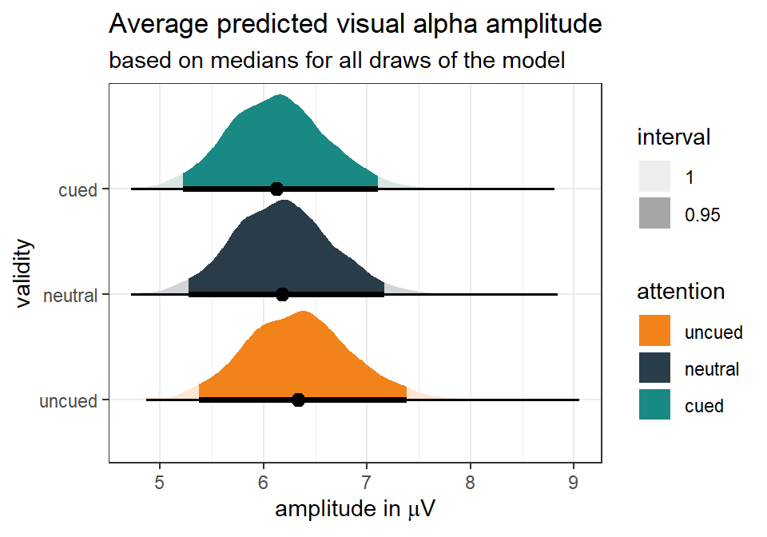

```r
# now gather all the single draws to be able to plot the variance predicted RTs for different validity levels
bestmodel.ef.ef_draws_validity <- bestmodel.ef.model %>%
  emmeans(~ attention,
          epred = TRUE)%>%
  gather_emmeans_draws()

theme_set(theme_bw())
g <- ggplot(bestmodel.ef.ef_draws_validity, aes(y = attention, x = .value)) +
  stat_halfeye(
    aes(fill = attention, fill_ramp = after_stat(level)),
    .width = c(.95, 1),
    position = "dodgejust",
  ) +
  scale_fill_manual(values=c("#F1831A", "#293C4A", "#198A83")) +
  scale_color_manual(values=c("#F1831A", "#293C4A", "#198A83"))+
  labs(
    title = "Average predicted visual alpha amplitude",
    subtitle = "based on medians for all draws of the model",
    fill_ramp = "interval",
    x = expression(paste("amplitude in ", mu, "V")),
    y = "validity"
  )

print(g)
```

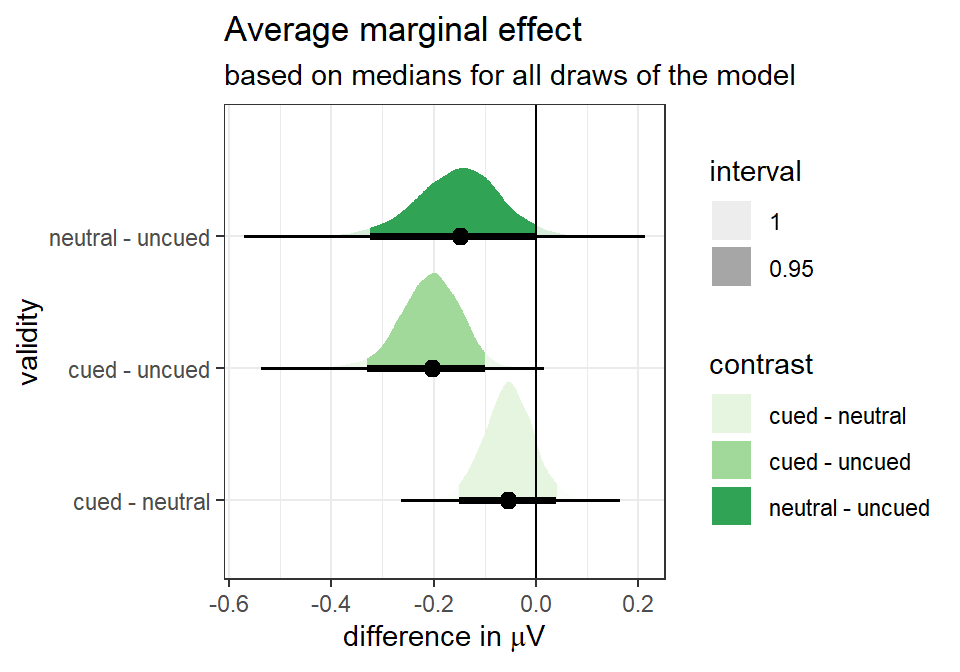

```r
# ggsave(filename = "figures/MarginEffects_visAlphapredicted_by_validity_predictvals.eps", width = 5, height = 3.5,
#        plot = print(g))



# now gather all the single draws to be able to plot the variance of the contrast
bestmodel.ef.ef_draws_validity_contr <- bestmodel.ef.model %>%
  emmeans(~ attention,
          epred = TRUE)%>%
  contrast(method = "revpairwise") %>%
  gather_emmeans_draws()

theme_set(theme_bw())
g <- ggplot(bestmodel.ef.ef_draws_validity_contr, aes(y = contrast, x = .value)) +
  stat_halfeye(
    aes(fill = contrast, fill_ramp = after_stat(level)),
    .width = c(.95, 1),
    position = "dodgejust",
  ) +
  geom_vline(xintercept = 0)+
  scale_fill_brewer(palette = "Greens")+
  labs(
    title = "Average marginal effect",
    subtitle = "based on medians for all draws of the model",
    fill_ramp = "interval",
    x = expression(paste("difference in ", mu, "V")),
    y = "validity"
  )

print(g)
```

```r
# ggsave(filename = "figures/MarginEffects_visAlphapredicted_by_validity_contrasts.eps", width = 5, height = 3.5,
#        plot = print(g))
```

## Extract marginal effects from motor alpha model

```r
# based on https://www.andrewheiss.com/blog/2021/11/10/ame-bayes-re-guide/
# which model to use?
bestmodel.ef.model <- fit_EEG_mot_alpha_validity
# what is the data of the model?
bestmodel.ef.data <- bestmodel.ef.model$data

# see data
#head(bestmodel.ef.data)

# show effects of the model
tidy(bestmodel.ef.model)%>%
  kable(escape = F, digits = c(6,6,6,6,6,6,6,6,6), caption = c("effects of best model")) %>%
  kable_styling("striped", full_width = T, bootstrap_options = c("striped", "hover", "condensed", "responsive",font_size = 8))
```

effects of best model

| effect | component | group | term | estimate | std.error | conf.low | conf.high |
| --- | --- | --- | --- | --- | --- | --- | --- |
| fixed | cond | NA | (Intercept) | 1.460667 | 0.075174 | 1.308733 | 1.604839 |
| fixed | cond | NA | attention.L | -0.048733 | 0.012614 | -0.073504 | -0.022978 |
| fixed | cond | NA | attention.Q | -0.015263 | 0.006741 | -0.028536 | -0.002617 |
| ran_pars | cond | subject | sd__(Intercept) | 0.391090 | 0.058433 | 0.298570 | 0.524502 |
| ran_pars | cond | subject | sd__attention.L | 0.063136 | 0.010409 | 0.046008 | 0.087420 |
| ran_pars | cond | subject | sd__attention.Q | 0.013720 | 0.009569 | 0.000515 | 0.034574 |
| ran_pars | cond | subject | cor__(Intercept).attention.L | -0.250376 | 0.180570 | -0.573176 | 0.120314 |
| ran_pars | cond | subject | cor__(Intercept).attention.Q | -0.159542 | 0.396982 | -0.848205 | 0.707397 |
| ran_pars | cond | subject | cor__attention.L.attention.Q | -0.017824 | 0.403172 | -0.786906 | 0.782511 |
| ran_pars | cond | Residual | sd__Observation | 0.402555 | 0.003608 | 0.395600 | 0.409783 |

Based on the new data we can extract **predicted values** or **expected predicted values**. The former also includes the uncertainty for each individual observation (e.g., observational-level residual variance) of each prediction. We’re however more interested in the latter, which more focusses on the uncertainty in the model parameters and not necessarily the individual-level residuals.

```r
# use range of data from orignal study
bestmodel.ef.newdata <- expand_grid(
  attention = as.factor(c('uncued','neutral','cued')),
  # post_cue_vis_alpha_contra_target = median(bestmodel.ef.data$post_cue_vis_alpha_contra_target),
  # contra_nontarget = median(bestmodel.ef.data$contra_nontarget),
  # contra_target = seq(min(bestmodel.ef.data$contra_target),max(bestmodel.ef.data$contra_target),1),
  # contra_nontarget = seq(min(bestmodel.ef.data$contra_nontarget),max(bestmodel.ef.data$contra_nontarget),1),
  # subject = as.factor(unique(bestmodel.ef.data$subject))
  subject = as.factor(c(120)) # for a 'new' subject
)%>%
  mutate(attention = factor(attention, levels=c('uncued','neutral','cued'), ordered = T))

# use 'predicted_draws' to draw from posterior predictive distribution
# this still incorporates variance of each individual observation in the model
# we may not want to have this around for marginal effects, awe we're more focused on the expected value
bestmodel.ef.tidy_pred <- bestmodel.ef.model %>%
  predicted_draws(newdata = bestmodel.ef.newdata, allow_new_levels = TRUE)
# head(bestmodel.ef.tidy_pred)%>%
#   kable(escape = F, digits = c(6,6,6,6,6,6,6,6,6), caption = c("predicted data")) %>%
#   kable_styling("striped", full_width = T, bootstrap_options = c("striped", "hover", "condensed", "responsive",font_size = 8))
#


# use 'expected draws' ('epred_draws') as we're more intereste in the expected value of the outcome
# which means we’re more focused on the uncertainty in the model parameters and not necessarily the individual-level residuals
# same as fitte function (only with nicer wrapper)
bestmodel.ef.tidy_exppred <- bestmodel.ef.model %>%
  epred_draws(newdata = bestmodel.ef.newdata, allow_new_levels = TRUE)
# head(bestmodel.ef.tidy_exppred)%>%
#   kable(escape = F, digits = c(6,6,6,6,6,6,6,6,6), caption = c("predicted data")) %>%
#   kable_styling("striped", full_width = T, bootstrap_options = c("striped", "hover", "condensed", "responsive",font_size = 8))
#
```

```r
# now we want to see the effects using emmeans
# check cue validity effect via pairwise comparisons
# first the emmeans (point estimate = median of distrbution)
bestmodel.ef.model %>%
  emmeans(~ attention,
          epred = TRUE)%>%
  kable(escape = F, digits = c(3,3,3,6,3,3,3,3,3),
        caption = c("average marginal effect | point measure = median of SSVEP amplitude")) %>%
  # kable_classic(full_width = F) %>%
  column_spec(1, bold = T)%>%
  kable_styling("striped", full_width = T, bootstrap_options = c("striped", "hover", "condensed", "responsive",font_size = 8))
```

| attention | emmean | lower.HPD | upper.HPD |
| --- | --- | --- | --- |
| uncued | 5.506 | 4.803 | 6.225926 |
| neutral | 5.428 | 4.778 | 6.173245 |
| cued | 5.182 | 4.588 | 5.858955 |

```r
# pairwise comparisons
bestmodel.ef.model %>%
  emmeans(~ attention,
          epred = TRUE)%>%
  contrast(method = "revpairwise")%>%
  kable(escape = F, digits = c(3,3,3,6,3,3,3,3,3),
        caption = c("average marginal effect differences | point measure = median of SSVEP amplitude")) %>%
  # kable_classic(full_width = F) %>%
  column_spec(1, bold = T)%>%
  kable_styling("striped", full_width = T, bootstrap_options = c("striped", "hover", "condensed", "responsive",font_size = 8))
```

| contrast | estimate | lower.HPD | upper.HPD |
| --- | --- | --- | --- |
| neutral - uncued | -0.075 | -0.193 | 0.037645 |
| cued - uncued | -0.320 | -0.505 | -0.140267 |
| cued - neutral | -0.247 | -0.372 | -0.127458 |

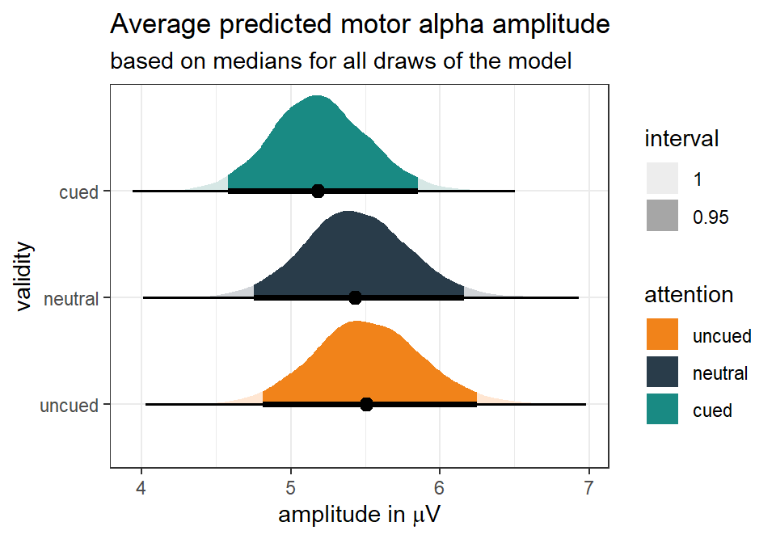

```r
# now gather all the single draws to be able to plot the variance predicted RTs for different validity levels
bestmodel.ef.ef_draws_validity <- bestmodel.ef.model %>%
  emmeans(~ attention,
          epred = TRUE)%>%
  gather_emmeans_draws()

theme_set(theme_bw())
g <- ggplot(bestmodel.ef.ef_draws_validity, aes(y = attention, x = .value)) +
  stat_halfeye(
    aes(fill = attention, fill_ramp = after_stat(level)),
    .width = c(.95, 1),
    position = "dodgejust",
  ) +
  scale_fill_manual(values=c("#F1831A", "#293C4A", "#198A83")) +
  scale_color_manual(values=c("#F1831A", "#293C4A", "#198A83"))+
  labs(
    title = "Average predicted motor alpha amplitude",
    subtitle = "based on medians for all draws of the model",
    fill_ramp = "interval",
    x = expression(paste("amplitude in ", mu, "V")),
    y = "validity"
  )

print(g)
```

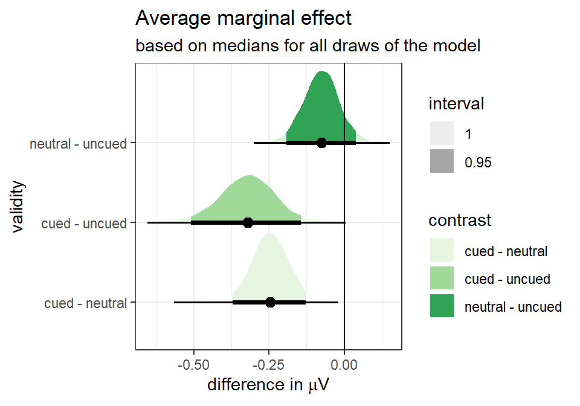

```r
# ggsave(filename = "figures/MarginEffects_motAlphapredicted_by_validity_predictvals.eps", width = 5, height = 3.5,
#        plot = print(g))



# now gather all the single draws to be able to plot the variance of the contrast
bestmodel.ef.ef_draws_validity_contr <- bestmodel.ef.model %>%
  emmeans(~ attention,
          epred = TRUE)%>%
  contrast(method = "revpairwise") %>%
  gather_emmeans_draws()

theme_set(theme_bw())
g <- ggplot(bestmodel.ef.ef_draws_validity_contr, aes(y = contrast, x = .value)) +
  stat_halfeye(
    aes(fill = contrast, fill_ramp = after_stat(level)),
    .width = c(.95, 1),
    position = "dodgejust",
  ) +
  geom_vline(xintercept = 0)+
  scale_fill_brewer(palette = "Greens")+
  labs(
    title = "Average marginal effect",
    subtitle = "based on medians for all draws of the model",
    fill_ramp = "interval",
    x = expression(paste("difference in ", mu, "V")),
    y = "validity"
  )

print(g)
```

```r
# ggsave(filename = "figures/MarginEffects_motAlphapredicted_by_validity_contrats.eps", width = 5, height = 3.5,
#        plot = print(g))
```

## Extract marginal effects from SSVEP complex model alpha model

```r
# based on https://www.andrewheiss.com/blog/2021/11/10/ame-bayes-re-guide/
# which model to use?
bestmodel.ef.model <- fit_EEG_SSVEP_validity_x_alpha

# what is the data of the model?
bestmodel.ef.data <- bestmodel.ef.model$data

# see data
#head(bestmodel.ef.data)

# show effects of the model
tidy(bestmodel.ef.model)%>%
  kable(escape = F, digits = c(6,6,6,6,6,6,6,6,6), caption = c("effects of best model")) %>%
  kable_styling("striped", full_width = T, bootstrap_options = c("striped", "hover", "condensed", "responsive",font_size = 8))
```

effects of best model

| effect | component | group | term | estimate | std.error | conf.low | conf.high |
| --- | --- | --- | --- | --- | --- | --- | --- |
| fixed | cond | NA | (Intercept) | 1.298831 | 0.077244 | 1.137151 | 1.450614 |
| fixed | cond | NA | attention.L | 0.028654 | 0.017951 | -0.006549 | 0.064733 |
| fixed | cond | NA | attention.Q | -0.005388 | 0.018900 | -0.041672 | 0.032226 |
| fixed | cond | NA | visualAlpha | 0.004429 | 0.001858 | 0.000780 | 0.008106 |
| fixed | cond | NA | attention.L:visualAlpha | -0.000637 | 0.002199 | -0.004883 | 0.003654 |
| fixed | cond | NA | attention.Q:visualAlpha | -0.002023 | 0.002499 | -0.006894 | 0.002884 |
| ran_pars | cond | subject | sd__(Intercept) | 0.394062 | 0.057332 | 0.300038 | 0.517621 |
| ran_pars | cond | subject | sd__attention.L | 0.038047 | 0.010658 | 0.018835 | 0.060910 |
| ran_pars | cond | subject | sd__attention.Q | 0.014151 | 0.010167 | 0.000603 | 0.038189 |
| ran_pars | cond | subject | cor__(Intercept).attention.L | -0.066638 | 0.249512 | -0.541314 | 0.415194 |
| ran_pars | cond | subject | cor__(Intercept).attention.Q | -0.273379 | 0.430990 | -0.906512 | 0.680015 |
| ran_pars | cond | subject | cor__attention.L.attention.Q | -0.025437 | 0.476209 | -0.867882 | 0.844226 |
| ran_pars | cond | Residual | sd__Observation | 0.574339 | 0.002795 | 0.568843 | 0.579948 |

We then create a new data set with an alpha amplitude value fixed at the median of the original data, to be able to illustrate the distribution of the marginal means and their effect for the attentional cue, i.e. the factor **validity**

Based on the new data we can extract **predicted values** or **expected predicted values**. The former also includes the uncertainty for each individual observation (e.g., observational-level residual variance) of each prediction. We’re however more interested in the latter, which more focusses on the uncertainty in the model parameters and not necessarily the individual-level residuals.

```r
# use range of data from orignal study
bestmodel.ef.newdata <- expand_grid(
  attention = as.factor(c('uncued','neutral','cued')),
  visualAlpha = median(bestmodel.ef.data$visualAlpha),
  # post_cue_vis_alpha_contra_target = median(bestmodel.ef.data$post_cue_vis_alpha_contra_target),
  # contra_nontarget = median(bestmodel.ef.data$contra_nontarget),
  # contra_target = seq(min(bestmodel.ef.data$contra_target),max(bestmodel.ef.data$contra_target),1),
  # contra_nontarget = seq(min(bestmodel.ef.data$contra_nontarget),max(bestmodel.ef.data$contra_nontarget),1),
  # subject = as.factor(unique(bestmodel.ef.data$subject))
  subject = as.factor(c(120)) # for a 'new' subject
)%>%
  mutate(attention = factor(attention, levels=c('uncued','neutral','cued'), ordered = T))

# use 'predicted_draws' to draw from posterior predictive distribution
# this still incorporates variance of each individual observation in the model
# we may not want to have this around for marginal effects, awe we're more focused on the expected value
bestmodel.ef.tidy_pred <- bestmodel.ef.model %>%
  predicted_draws(newdata = bestmodel.ef.newdata, allow_new_levels = TRUE)
# head(bestmodel.ef.tidy_pred)%>%
#   kable(escape = F, digits = c(6,6,6,6,6,6,6,6,6), caption = c("predicted data")) %>%
#   kable_styling("striped", full_width = T, bootstrap_options = c("striped", "hover", "condensed", "responsive",font_size = 8))
#


# use 'expected draws' ('epred_draws') as we're more intereste in the expected value of the outcome
# which means we’re more focused on the uncertainty in the model parameters and not necessarily the individual-level residuals
# same as fitte function (only with nicer wrapper)
bestmodel.ef.tidy_exppred <- bestmodel.ef.model %>%
  epred_draws(newdata = bestmodel.ef.newdata, allow_new_levels = TRUE)
# head(bestmodel.ef.tidy_exppred)%>%
#   kable(escape = F, digits = c(6,6,6,6,6,6,6,6,6), caption = c("predicted data")) %>%
#   kable_styling("striped", full_width = T, bootstrap_options = c("striped", "hover", "condensed", "responsive",font_size = 8))
#
```

```r
# now we want to see the effects using emmeans
# check cue validity effect via pairwise comparisons
# first the emmeans (point estimate = median of distrbution)
bestmodel.ef.model %>%
  emmeans(~ attention,
          epred = TRUE)%>%
  kable(escape = F, digits = c(3,3,3,6,3,3,3,3,3),
        caption = c("average marginal effect | point measure = median of SSVEP amplitude")) %>%
  # kable_classic(full_width = F) %>%
  column_spec(1, bold = T)%>%
  kable_styling("striped", full_width = T, bootstrap_options = c("striped", "hover", "condensed", "responsive",font_size = 8))
```

average marginal effect | point measure = median of SSVEP amplitude

| attention | emmean | lower.HPD | upper.HPD |
| --- | --- | --- | --- |
| uncued | 4.348 | 3.679 | 5.016853 |
| neutral | 4.531 | 3.813 | 5.225202 |
| cued | 4.500 | 3.842 | 5.222772 |

```r
# pairwise comparisons
bestmodel.ef.model %>%
  emmeans(~ attention,
          epred = TRUE)%>%
  contrast(method = "revpairwise")%>%
  kable(escape = F, digits = c(3,3,3,6,3,3,3,3,3),
        caption = c("average marginal effect differences | point measure = median of SSVEP amplitude")) %>%
  # kable_classic(full_width = F) %>%
  column_spec(1, bold = T)%>%
  kable_styling("striped", full_width = T, bootstrap_options = c("striped", "hover", "condensed", "responsive",font_size = 8))
```

average marginal effect differences | point measure = median of SSVEP amplitude

| contrast | estimate | lower.HPD | upper.HPD |
| --- | --- | --- | --- |
| neutral - uncued | 0.181 | 0.062 | 0.293504 |
| cued - uncued | 0.152 | 0.030 | 0.273534 |
| cued - neutral | -0.029 | -0.149 | 0.075870 |

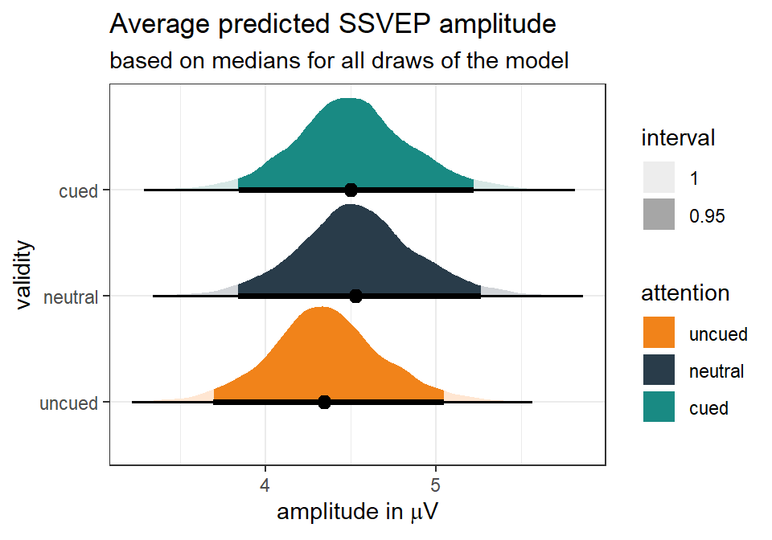

```r
# now gather all the single draws to be able to plot the variance predicted RTs for different validity levels
bestmodel.ef.ef_draws_validity <- bestmodel.ef.model %>%
  emmeans(~ attention,
          epred = TRUE)%>%
  gather_emmeans_draws()

theme_set(theme_bw())
g <-ggplot(bestmodel.ef.ef_draws_validity, aes(y = attention, x = .value)) +
  stat_halfeye(
    aes(fill = attention, fill_ramp = after_stat(level)),
    .width = c(.95, 1),
    position = "dodgejust",
  ) +
  scale_fill_manual(values=c("#F1831A", "#293C4A", "#198A83")) +
  scale_color_manual(values=c("#F1831A", "#293C4A", "#198A83"))+
  labs(
    title = "Average predicted SSVEP amplitude",
    subtitle = "based on medians for all draws of the model",
    fill_ramp = "interval",
    x = expression(paste("amplitude in ", mu, "V")),
    y = "validity"
  )

print(g)
```

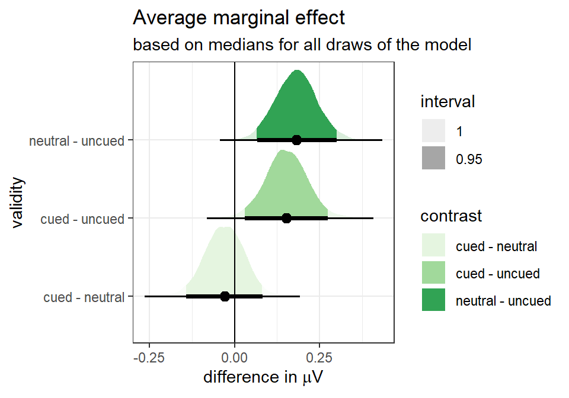

```r
# ggsave(filename = "figures/MarginEffects_SSVEPpredicted_by_validityXvisalpha_predictvals.eps", width = 5, height = 3.5,
#        plot = print(g))


# now gather all the single draws to be able to plot the variance of the contrast
bestmodel.ef.ef_draws_validity_contr <- bestmodel.ef.model %>%
  emmeans(~ attention,
          epred = TRUE)%>%
  contrast(method = "revpairwise") %>%
  gather_emmeans_draws()

theme_set(theme_bw())
g <- ggplot(bestmodel.ef.ef_draws_validity_contr, aes(y = contrast, x = .value)) +
  stat_halfeye(
    aes(fill = contrast, fill_ramp = after_stat(level)),
    .width = c(.95, 1),
    position = "dodgejust",
  ) +
  geom_vline(xintercept = 0)+
  scale_fill_brewer(palette = "Greens")+
  labs(
    title = "Average marginal effect",
    subtitle = "based on medians for all draws of the model",
    fill_ramp = "interval",
    x = expression(paste("difference in ", mu, "V")),
    y = "validity"
  )

print(g)
```

```r
# ggsave(filename = "figures/MarginEffects_SSVEPpredicted_by_validityXvisalpha_contrasts.eps", width = 5, height = 3.5,
#        plot = print(g))
```

```r
# now trying to get the regression line right for the alpha predictors

## alpha
# use range of data from orignal study with varying alpha contra target (in range of original data)
bestmodel.ef.newdata2 <- expand_grid(
  attention = as.factor(c('uncued','neutral','cued')),
  visualAlpha = seq(min(bestmodel.ef.data$visualAlpha),max(bestmodel.ef.data$visualAlpha),1),
  # post_cue_vis_alpha_contra_target = median(bestmodel.ef.data$post_cue_vis_alpha_contra_target),
  # contra_nontarget = median(bestmodel.ef.data$contra_nontarget),
  # contra_target = seq(min(bestmodel.ef.data$contra_target),max(bestmodel.ef.data$contra_target),1),
  # contra_nontarget = seq(min(bestmodel.ef.data$contra_nontarget),max(bestmodel.ef.data$contra_nontarget),1),
  # subject = as.factor(unique(bestmodel.ef.data$subject))
  subject = as.factor(c(120)) # for a 'new' subject
)%>%
  mutate(attention = factor(attention, levels=c('uncued','neutral','cued'), ordered = T))

# use 'expected draws' ('epred_draws') as we're more intereste in the expected value of the outcome
# which means we’re more focused on the uncertainty in the model parameters and not necessarily the individual-level residuals
# same as fitte function (only with nicer wrapper)
bestmodel.ef.tidy_exppred2 <- bestmodel.ef.model %>%
  epred_draws(newdata = bestmodel.ef.newdata2, allow_new_levels = TRUE)
head(bestmodel.ef.tidy_exppred2)%>%
  kable(escape = F, digits = c(6,6,6,6,6,6,6,6,6), caption = c("predicted data")) %>%
  kable_styling("striped", full_width = T, bootstrap_options = c("striped", "hover", "condensed", "responsive",font_size = 8))
```

predicted data

| attention | visualAlpha | subject | .row | .chain | .iteration | .draw | .epred |
| --- | --- | --- | --- | --- | --- | --- | --- |
| uncued | 1.663777 | 120 | 1 | NA | NA | 1 | 5.024746 |
| uncued | 1.663777 | 120 | 1 | NA | NA | 2 | 5.272604 |
| uncued | 1.663777 | 120 | 1 | NA | NA | 3 | 3.536875 |
| uncued | 1.663777 | 120 | 1 | NA | NA | 4 | 5.646629 |
| uncued | 1.663777 | 120 | 1 | NA | NA | 5 | 4.814342 |
| uncued | 1.663777 | 120 | 1 | NA | NA | 6 | 4.053095 |

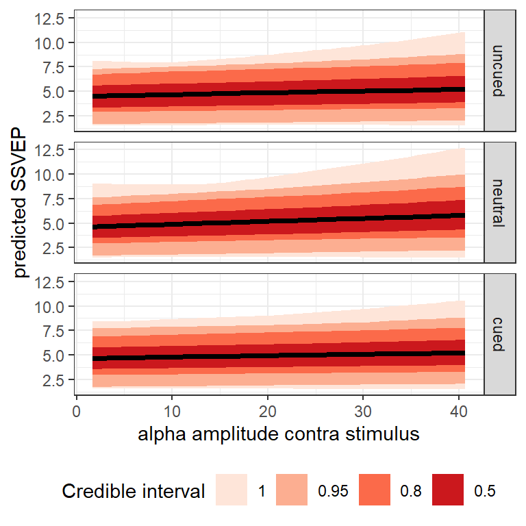

```r
theme_set(theme_bw())
ggplot(bestmodel.ef.tidy_exppred2, aes(x = visualAlpha, y = .epred)) +
  stat_lineribbon(.width = c(0.5, 0.8, 0.95, 1)) +
  scale_fill_brewer(palette = "Reds") +
  facet_grid(attention~.)+
  labs(x = "alpha amplitude contra stimulus", y = "predicted SSVEP",
       fill = "Credible interval") +
  theme(legend.position = "bottom")
```

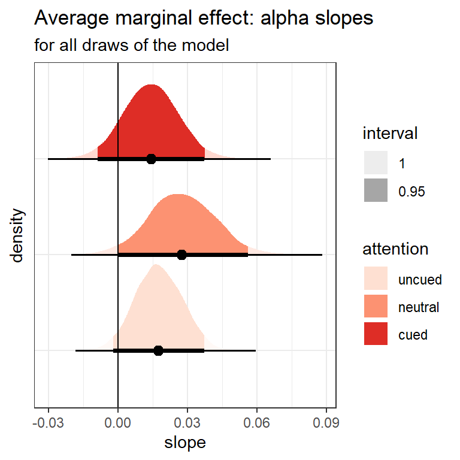

```r
# now lets get the slop of the modulation by alpha
bestmodel.ef.slope_contraTarget <- bestmodel.ef.model %>%
  emtrends(~ attention, # 1 means, we want the average slop
           var = "visualAlpha",
           epred = TRUE) %>%
  gather_emmeans_draws()



theme_set(theme_bw())
ggplot(bestmodel.ef.slope_contraTarget, aes( x = .value, y=attention)) +
  stat_halfeye(
    aes(fill = attention, fill_ramp = after_stat(level)),
    .width = c(.95, 1),
  ) +
  # stat_dots(aes(fill = alpha_signal,color = alpha_signal, fill_ramp = after_stat(level), colour_ramp = after_stat(level)),
  #           .width = c(.95, 1))+
  geom_vline(xintercept = 0)+
  # scale_fill_manual(values=c("red3")) +
  scale_color_brewer(palette = "Reds") +
  scale_fill_brewer(palette = "Reds") +
  labs(
    title = "Average marginal effect: alpha slopes",
    subtitle = "for all draws of the model",
    fill_ramp = "interval",
    colour_ramp = "interval",
    x = "slope",
    y = "density",
  )+
  theme(axis.text.y=element_blank(),axis.ticks.y=element_blank())
```

```r
bestmodel.ef.slope_contraTarget %>% median_hdi() %>%
  kable(escape = F, digits = c(6,6,6,6,6,6,6,6,6), caption = c("alpha slope: mean and CI")) %>%
  kable_styling("striped", full_width = T, bootstrap_options = c("striped", "hover", "condensed", "responsive",font_size = 8))
```

| attention | .value | .lower | .upper | .width | .point | .interval |
| --- | --- | --- | --- | --- | --- | --- |
| uncued | 0.017392 | -0.002398 | 0.036865 | 0.95 | median | hdi |
| neutral | 0.027415 | -0.001197 | 0.054496 | 0.95 | median | hdi |
| cued | 0.014206 | -0.010005 | 0.035704 | 0.95 | median | hdi |